# 📖 Notebook 02: Self-Attention（自己注意機構）

## — Transformer の心臓部を数値で追う —

### なぜ Attention が必要か

**「銀行」** という単語の意味は文脈によって変わります：

- 「**川の** 銀行 **に立つ**」→ 川岸
- 「**お金を** 銀行 **に預ける**」→ 金融機関

RNN（前世代のモデル）は左から右に処理するため、遠い文脈を参照しにくいという問題がありました。 **Self-Attention** は全トークンを**並列に・直接**参照できます。

### 計算の全体像

$$\text{Attention}(Q, K, V) = \text{softmax}\!\left(\frac{QK^\top}{\sqrt{d_k}}\right)V$$

| 記号 | 名前 | 役割 | 検索エンジンの比喩 |
| --- | --- | --- | --- |
| **Q** | Query（クエリ） | 何を探しているか | 検索ワード |
| **K** | Key（キー） | どんな情報を持つか | 文書のタグ |
| **V** | Value（バリュー） | 参照されたときに渡す情報 | 文書の中身 |

```python
import numpy as np
import matplotlib.pyplot as plt
import matplotlib.colors as mcolors

np.random.seed(42)
np.set_printoptions(precision=4, suppress=True)
plt.rcParams.update({'font.size': 11, 'figure.dpi': 110, 'font.family': 'IPAGothic'})

# NB01 の設定を再現
vocab_size = 8
d_model    = 4
seq_len    = 4
tokens     = [2, 5, 1, 3]

def positional_encoding(seq_len, d_model):
    PE = np.zeros((seq_len, d_model))
    for pos in range(seq_len):
        for i in range(0, d_model, 2):
            angle = pos / (10000 ** (2 * i / d_model))
            PE[pos, i]   = np.sin(angle)
            if i + 1 < d_model:
                PE[pos, i+1] = np.cos(angle)
    return PE

np.random.seed(42)
E = np.random.randn(vocab_size, d_model)
X = E[tokens] + positional_encoding(seq_len, d_model)

print(f"入力 X: shape = {X.shape}")
print(X)
```

```
入力 X: shape = (4, 4)
[[-0.4695  1.5426 -0.4634  0.5343]
 [ 2.3071  0.3145  0.0676 -0.4247]
 [ 0.6751 -0.6503  1.5794  1.7674]
 [ 0.3831 -2.9033 -1.7246  0.4377]]
```

## Step 1: Q・K・V 行列の生成

入力 $X$ に 3 種類の重み行列を掛けて Q/K/V を生成します：

$$Q = X W_Q \in \mathbb{R}^{L \times d_k}$$ $$K = X W_K \in \mathbb{R}^{L \times d_k}$$ $$V = X W_V \in \mathbb{R}^{L \times d_v}$$

- $W_Q, W_K, W_V \in \mathbb{R}^{d_{\text{model}} \times d_k}$ は学習パラメータ
- ここでは $d_k = d_{\text{model}} = 4$

**直感**：同じ X から 3 種類の「見せ方」を作る。 Q は「質問」、K は「索引」、V は「回答」の視点から X を変換します。

```python
np.random.seed(0)
d_k = d_model

W_Q = np.random.randn(d_model, d_k) * 0.5
W_K = np.random.randn(d_model, d_k) * 0.5
W_V = np.random.randn(d_model, d_k) * 0.5

Q = X @ W_Q   # (4,4) @ (4,4) = (4,4)
K = X @ W_K
V = X @ W_V

print(f"Q = X @ W_Q : shape = {Q.shape}")
print(Q)
print()
print(f"K = X @ W_K : shape = {K.shape}")
print(K)
print()
print(f"V = X @ W_V : shape = {V.shape}")
print(V)
```

```
Q = X @ W_Q : shape = (4, 4)
[[ 1.2535 -0.9103  0.5882 -0.8906]
 [ 2.1635  0.296   1.1891  2.5395]
 [ 0.5793  0.8846  0.5275  2.249 ]
 [-2.1176  1.1679 -1.2188 -0.5321]]

K = X @ W_K : shape = (4, 4)
[[-2.4362  1.2818  0.624  -0.2275]
 [ 1.0732 -0.4951  0.4657 -1.1886]
 [ 4.4814 -0.1318 -0.0023  0.1394]
 [ 2.3704  0.5876 -1.2004  1.1579]]

V = X @ W_V : shape = (4, 4)
[[ 1.2641  1.6043 -0.1564 -0.5142]
 [-0.7579 -2.0509 -0.2539  0.0337]
 [-1.9781 -2.5681 -2.4461  2.3787]
 [-1.1633 -0.9962  1.6928 -1.0432]]
```

```python
# Q[0] の手計算確認
print("━━━ 手計算確認: Q[0]（位置0のクエリベクトル）━━━")
print(f"X[0]  = {X[0]}")
print()
print("Q[0] = X[0] @ W_Q を要素ごとに計算:")
for j in range(d_k):
    val = np.dot(X[0], W_Q[:, j])
    terms = ' + '.join([f'{X[0][i]:.3f}×{W_Q[i,j]:.3f}' for i in range(d_model)])
    print(f"  Q[0,{j}] = {terms} = {val:.4f}")
print()
print(f"  計算値: {X[0] @ W_Q}")
print(f"  行列値: {Q[0]}  ✓")
```

```
━━━ 手計算確認: Q[0]（位置0のクエリベクトル）━━━
X[0]  = [-0.4695  1.5426 -0.4634  0.5343]

Q[0] = X[0] @ W_Q を要素ごとに計算:
  Q[0,0] = -0.469×0.882 + 1.543×0.934 + -0.463×-0.052 + 0.534×0.381 = 1.2535
  Q[0,1] = -0.469×0.200 + 1.543×-0.489 + -0.463×0.205 + 0.534×0.061 = -0.9103
  Q[0,2] = -0.469×0.489 + 1.543×0.475 + -0.463×0.072 + 0.534×0.222 = 0.5882
  Q[0,3] = -0.469×1.120 + 1.543×-0.076 + -0.463×0.727 + 0.534×0.167 = -0.8906

  計算値: [ 1.2535 -0.9103  0.5882 -0.8906]
  行列値: [ 1.2535 -0.9103  0.5882 -0.8906]  ✓
```

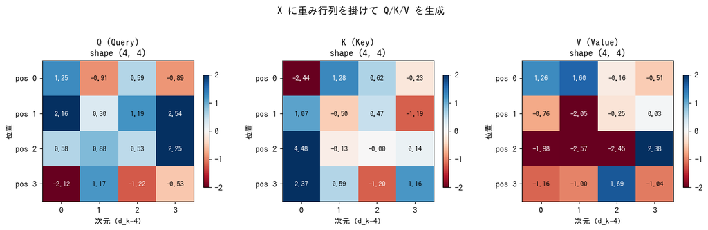

```python
# Q/K/V の可視化
fig, axes = plt.subplots(1, 3, figsize=(13, 4))
for ax, mat, name in zip(axes, [Q, K, V], ['Q (Query)', 'K (Key)', 'V (Value)']):
    im = ax.imshow(mat, cmap='RdBu', aspect='auto', vmin=-2, vmax=2)
    ax.set_title(f'{name}\nshape {mat.shape}', fontsize=12)
    ax.set_xlabel('次元 (d_k=4)', fontsize=10)
    ax.set_ylabel('位置', fontsize=10)
    ax.set_xticks(range(d_k))
    ax.set_yticks(range(seq_len))
    ax.set_yticklabels([f'pos {i}' for i in range(seq_len)])
    for i in range(seq_len):
        for j in range(d_k):
            ax.text(j, i, f'{mat[i,j]:.2f}', ha='center', va='center',
                    fontsize=9, color='white' if abs(mat[i,j]) > 1.2 else 'black')
    plt.colorbar(im, ax=ax, shrink=0.8)

plt.suptitle('X に重み行列を掛けて Q/K/V を生成', fontsize=13, y=1.02)
plt.tight_layout()
plt.savefig('docs/nb02_qkv.png', dpi=120, bbox_inches='tight')
plt.show()
```

## Step 2: Attention スコアの計算

$$\text{scores} = \frac{QK^\top}{\sqrt{d_k}} \in \mathbb{R}^{L \times L}$$

`scores[i, j]` = 位置 i のトークンが位置 j のトークンを「どれだけ参照したいか」

**なぜ $\sqrt{d_k}$ で割るか：**

- $d_k$ が大きいほど内積の値も大きくなり、softmax が極端な分布になる
- $\sqrt{d_k}$ で割ることで分散を 1 付近に正規化する

証明：$x, y \sim \mathcal{N}(0,1)$ のとき $x \cdot y \sim \mathcal{N}(0, d_k)$  
→ $\sqrt{d_k}$ で割れば $\mathcal{N}(0,1)$ に戻る

```python
# スケーリング前後の比較
scores_raw    = Q @ K.T
scores_scaled = scores_raw / np.sqrt(d_k)

print(f"Scale = √d_k = √{d_k} = {np.sqrt(d_k):.4f}")
print()
print(f"Step 2a: Q @ K^T (スケール前)  shape = {scores_raw.shape}")
print(scores_raw)
print()
print(f"Step 2b: / √{d_k} (スケール後):")
print(scores_scaled)
```

```
Scale = √d_k = √4 = 2.0000

Step 2a: Q @ K^T (スケール前)  shape = (4, 4)
[[-3.6511  3.1286  5.6121  0.6991]
 [-4.7274 -0.2892 10.0078  6.8156]
 [-0.46   -2.2438  2.7917  3.864 ]
 [ 6.0164 -2.7861 -9.7149 -3.4863]]

Step 2b: / √4 (スケール後):
[[-1.8255  1.5643  2.8061  0.3496]
 [-2.3637 -0.1446  5.0039  3.4078]
 [-0.23   -1.1219  1.3959  1.932 ]
 [ 3.0082 -1.393  -4.8575 -1.7432]]
```

```python
# scores[1, 2] の手計算
print("━━━ 手計算確認: scores[1, 2]（位置1が位置2を参照するスコア）━━━")
print(f"Q[1] = {Q[1]}")
print(f"K[2] = {K[2]}")
print()
dot_product = np.dot(Q[1], K[2])
terms = ' + '.join([f'{Q[1][i]:.4f}×{K[2][i]:.4f}' for i in range(d_k)])
print(f"Q[1] · K[2] = {terms}")
for i in range(d_k):
    print(f"              {Q[1][i]*K[2][i]:.6f}")
print(f"            = {dot_product:.4f}")
print(f"            / √{d_k} = {dot_product/np.sqrt(d_k):.4f}")
print(f"行列値 scores_scaled[1,2] = {scores_scaled[1,2]:.4f}  ✓")
```

```
━━━ 手計算確認: scores[1, 2]（位置1が位置2を参照するスコア）━━━
Q[1] = [2.1635 0.296  1.1891 2.5395]
K[2] = [ 4.4814 -0.1318 -0.0023  0.1394]

Q[1] · K[2] = 2.1635×4.4814 + 0.2960×-0.1318 + 1.1891×-0.0023 + 2.5395×0.1394
              9.695669
              -0.039007
              -0.002754
              0.353903
            = 10.0078
            / √4 = 5.0039
行列値 scores_scaled[1,2] = 5.0039  ✓
```

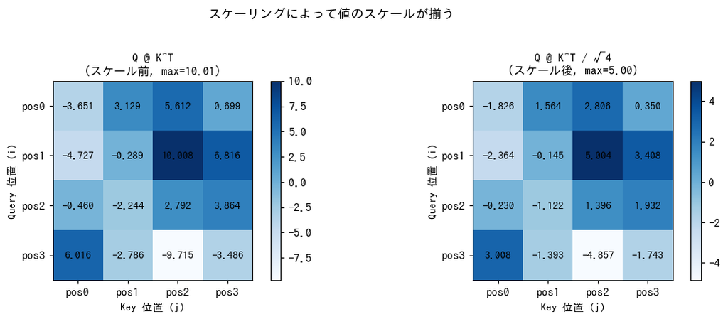

```python
# スケーリングの効果を可視化
fig, axes = plt.subplots(1, 2, figsize=(11, 4))
for ax, mat, title in zip(axes,
    [scores_raw, scores_scaled],
    [f'Q @ K^T\n（スケール前, max={scores_raw.max():.2f}）',
     f'Q @ K^T / √{d_k}\n（スケール後, max={scores_scaled.max():.2f}）']):
    im = ax.imshow(mat, cmap='Blues', aspect='equal')
    ax.set_title(title, fontsize=11)
    ax.set_xlabel('Key 位置 (j)', fontsize=10)
    ax.set_ylabel('Query 位置 (i)', fontsize=10)
    ax.set_xticks(range(seq_len)); ax.set_yticks(range(seq_len))
    ax.set_xticklabels([f'pos{j}' for j in range(seq_len)])
    ax.set_yticklabels([f'pos{i}' for i in range(seq_len)])
    for i in range(seq_len):
        for j in range(seq_len):
            ax.text(j, i, f'{mat[i,j]:.3f}', ha='center', va='center', fontsize=10)
    plt.colorbar(im, ax=ax)

plt.suptitle('スケーリングによって値のスケールが揃う', fontsize=12, y=1.02)
plt.tight_layout()
plt.savefig('docs/nb02_scores.png', dpi=120, bbox_inches='tight')
plt.show()
```

## Step 3: Causal Mask（因果マスク）

GPT 系の **デコーダ** は「未来のトークンを参照してはいけない」ルールがあります。 （エンコーダは双方向なのでマスク不要）

**なぜか：** テキスト生成時は未来のトークンが存在しない。 学習時にもその条件を揃えるため、上三角をマスクします。

$$\text{scores\_masked}[i,j] = \begin{cases} \text{scores}[i,j] & (j \leq i) \\ -\infty & (j > i) \end{cases}$$

$-\infty$ を softmax に入れると $e^{-\infty} = 0$ になり、参照確率が 0 になります。

```python
causal_mask   = np.triu(np.ones((seq_len, seq_len), dtype=bool), k=1)
scores_masked = scores_scaled.copy()
scores_masked[causal_mask] = -1e9

print("Causal Mask（True = 参照禁止）:")
print(causal_mask.astype(int))
print()
print("スコア（マスク前）:")
print(scores_scaled)
print()
print("スコア（マスク後）:")
print(scores_masked)
print()
print("→ 上三角（未来参照）が -1e9 に置き換えられた")
```

```
Causal Mask（True = 参照禁止）:
[[0 1 1 1]
 [0 0 1 1]
 [0 0 0 1]
 [0 0 0 0]]

スコア（マスク前）:
[[-1.8255  1.5643  2.8061  0.3496]
 [-2.3637 -0.1446  5.0039  3.4078]
 [-0.23   -1.1219  1.3959  1.932 ]
 [ 3.0082 -1.393  -4.8575 -1.7432]]

スコア（マスク後）:
[[-1.8255e+00 -1.0000e+09 -1.0000e+09 -1.0000e+09]
 [-2.3637e+00 -1.4462e-01 -1.0000e+09 -1.0000e+09]
 [-2.3000e-01 -1.1219e+00  1.3959e+00 -1.0000e+09]
 [ 3.0082e+00 -1.3930e+00 -4.8575e+00 -1.7432e+00]]

→ 上三角（未来参照）が -1e9 に置き換えられた
```

## Step 4: Softmax → Attention 重み

各行（各クエリトークン）に独立に softmax を適用します：

$$\text{attn\_weights}[i,j] = \frac{e^{\text{scores}[i,j]}}{\sum_{k} e^{\text{scores}[i,k]}}$$

**結果**：

- 各行の合計 = 1（確率分布）
- マスク位置（-1e9）は $e^{-10^9} \approx 0$ となり実質 0

**数値安定化：** $e^{\text{large}}$ はオーバーフローする恐れがあるため、 最大値を引いてからべき乗します（値は変わらない）：

$$\text{softmax}(z_j) = \frac{e^{z_j - \max z}}{\sum_k e^{z_k - \max z}}$$

```python
def softmax(x, axis=-1):
    e = np.exp(x - x.max(axis=axis, keepdims=True))
    return e / e.sum(axis=axis, keepdims=True)

attn_weights = softmax(scores_masked, axis=-1)

print("Attention 重み（各行の合計 = 1）:")
print(attn_weights)
print()
print("各行の合計:", attn_weights.sum(axis=-1))
print()
```

```
Attention 重み（各行の合計 = 1）:
[[1.     0.     0.     0.    ]
 [0.0981 0.9019 0.     0.    ]
 [0.154  0.0631 0.7828 0.    ]
 [0.9792 0.012  0.0004 0.0085]]

各行の合計: [1. 1. 1. 1.]
```

```python
# 手計算確認: 位置2 の行（pos=2 は pos=0,1,2 のみ参照可）
print("━━━ 手計算確認: attn_weights[2, :]（位置2の行）━━━")
row = scores_masked[2]
row_max  = row[row > -1e8].max()   # マスク以外の最大値
row_exp  = np.exp(row - row.max())
row_norm = row_exp / row_exp.sum()

print(f"scores_masked[2] = {row}")
print(f"各要素 - max({row.max():.4f}): {row - row.max()}")
print(f"exp(...)        : {np.exp(row - row.max())}")
print(f"合計            : {np.exp(row - row.max()).sum():.4f}")
print(f"softmax         : {row_norm}")
print(f"行列値           : {attn_weights[2]}  ✓")
print()
print(f"位置3（未来）への重み = {attn_weights[2,3]:.6f} ≈ 0  ← マスクの効果")
```

```
━━━ 手計算確認: attn_weights[2, :]（位置2の行）━━━
scores_masked[2] = [-2.3000e-01 -1.1219e+00  1.3959e+00 -1.0000e+09]
各要素 - max(1.3959): [-1.6259e+00 -2.5177e+00  0.0000e+00 -1.0000e+09]
exp(...)        : [0.1967 0.0806 1.     0.    ]
合計            : 1.2774
softmax         : [0.154  0.0631 0.7828 0.    ]
行列値           : [0.154  0.0631 0.7828 0.    ]  ✓

位置3（未来）への重み = 0.000000 ≈ 0  ← マスクの効果
```

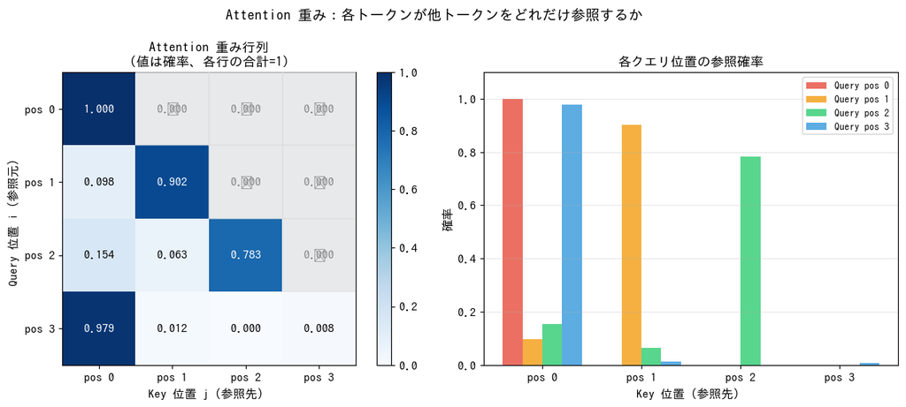

```python
# Attention 重みの可視化
fig, axes = plt.subplots(1, 2, figsize=(12, 5))

# 左: Attention ヒートマップ
im0 = axes[0].imshow(attn_weights, cmap='Blues', aspect='equal', vmin=0, vmax=1)
axes[0].set_title('Attention 重み行列\n（値は確率、各行の合計=1）', fontsize=12)
axes[0].set_xlabel('Key 位置 j（参照先）', fontsize=11)
axes[0].set_ylabel('Query 位置 i（参照元）', fontsize=11)
axes[0].set_xticks(range(seq_len))
axes[0].set_yticks(range(seq_len))
axes[0].set_xticklabels([f'pos {j}' for j in range(seq_len)])
axes[0].set_yticklabels([f'pos {i}' for i in range(seq_len)])

for i in range(seq_len):
    for j in range(seq_len):
        w = attn_weights[i, j]
        axes[0].text(j, i, f'{w:.3f}', ha='center', va='center',
                     fontsize=11, color='white' if w > 0.5 else 'black',
                     fontweight='bold')
        if causal_mask[i, j]:
            axes[0].add_patch(plt.Rectangle((j-0.5, i-0.5), 1, 1,
                                            fill=True, color='#ddd', alpha=0.6, zorder=5))
            axes[0].text(j, i, '✗', ha='center', va='center', fontsize=12,
                         color='#999', zorder=6)
plt.colorbar(im0, ax=axes[0])

# 右: 各クエリの参照パターン（棒グラフ）
x = np.arange(seq_len)
width = 0.2
colors = ['#e74c3c', '#f39c12', '#2ecc71', '#3498db']
for i in range(seq_len):
    axes[1].bar(x + i*width, attn_weights[i], width, label=f'Query pos {i}',
               color=colors[i], alpha=0.8)
axes[1].set_title('各クエリ位置の参照確率', fontsize=12)
axes[1].set_xlabel('Key 位置（参照先）', fontsize=11)
axes[1].set_ylabel('確率', fontsize=11)
axes[1].set_xticks(x + width*1.5)
axes[1].set_xticklabels([f'pos {j}' for j in range(seq_len)])
axes[1].legend(fontsize=9)
axes[1].set_ylim(0, 1.1)
axes[1].grid(True, alpha=0.3, axis='y')

plt.suptitle('Attention 重み：各トークンが他トークンをどれだけ参照するか', fontsize=13, y=1.02)
plt.tight_layout()
plt.savefig('docs/nb02_attention_weights.png', dpi=120, bbox_inches='tight')
plt.show()
```

## Step 5: V との重み付き和 → Attention 出力

$$\text{output} = \text{attn\_weights} \cdot V \in \mathbb{R}^{L \times d_v}$$

各トークンの出力ベクトル = 参照したトークンの Value ベクトルの**加重平均**です。

```python
attn_output = attn_weights @ V   # (4,4) @ (4,4) = (4,4)

print(f"Attention 出力 = attn_weights @ V : shape = {attn_output.shape}")
print(attn_output)
```

```
Attention 出力 = attn_weights @ V : shape = (4, 4)
[[ 1.2641  1.6043 -0.1564 -0.5142]
 [-0.5596 -1.6925 -0.2443 -0.0201]
 [-1.4017 -1.8928 -1.955   1.7851]
 [ 1.2181  1.5369 -0.1428 -0.511 ]]
```

```python
# 位置 2 の手計算確認
print("━━━ 手計算確認: output[2]（位置2の出力ベクトル）━━━")
print(f"attn_weights[2] = {attn_weights[2]}")
print()
manual = np.zeros(d_k)
for j in range(seq_len):
    w = attn_weights[2, j]
    contrib = w * V[j]
    manual += contrib
    print(f"  {w:.4f} × V[{j}]={V[j]}")
    print(f"  寄与 = {contrib}")
print()
print(f"合計  output[2] = {manual}")
print(f"行列値          = {attn_output[2]}  ✓")
```

```
━━━ 手計算確認: output[2]（位置2の出力ベクトル）━━━
attn_weights[2] = [0.154  0.0631 0.7828 0.    ]

  0.1540 × V[0]=[ 1.2641  1.6043 -0.1564 -0.5142]
  寄与 = [ 0.1947  0.2471 -0.0241 -0.0792]
  0.0631 × V[1]=[-0.7579 -2.0509 -0.2539  0.0337]
  寄与 = [-0.0478 -0.1295 -0.016   0.0021]
  0.7828 × V[2]=[-1.9781 -2.5681 -2.4461  2.3787]
  寄与 = [-1.5486 -2.0105 -1.9149  1.8622]
  0.0000 × V[3]=[-1.1633 -0.9962  1.6928 -1.0432]
  寄与 = [-0. -0.  0. -0.]

合計  output[2] = [-1.4017 -1.8928 -1.955   1.7851]
行列値          = [-1.4017 -1.8928 -1.955   1.7851]  ✓
```

```python
# 完全な Scaled Dot-Product Attention 関数
def scaled_dot_product_attention(Q, K, V, causal=True):
    """
    Vaswani et al. (2017) Eq.(1)
    Returns: output (L, d_v), weights (L, L)
    """
    seq_len, d_k = Q.shape
    scores = Q @ K.T / np.sqrt(d_k)
    if causal:
        mask = np.triu(np.ones((seq_len, seq_len), dtype=bool), k=1)
        scores[mask] = -1e9
    weights = softmax(scores, axis=-1)
    return weights @ V, weights

output_check, weights_check = scaled_dot_product_attention(Q, K, V)
print(f"関数版の出力（同じ値になるか確認）:")
print(output_check)
print()
print(f"上の手計算との差: {np.abs(output_check - attn_output).max():.2e}  ← 数値誤差のみ")
```

```
関数版の出力（同じ値になるか確認）:
[[ 1.2641  1.6043 -0.1564 -0.5142]
 [-0.5596 -1.6925 -0.2443 -0.0201]
 [-1.4017 -1.8928 -1.955   1.7851]
 [ 1.2181  1.5369 -0.1428 -0.511 ]]

上の手計算との差: 0.00e+00  ← 数値誤差のみ
```

## Multi-Head Attention（多頭注意機構）

1 つの Attention ヘッドでは 1 種類の「参照パターン」しか学べません。

**Multi-Head Attention** は $h$ 個の独立したヘッドを並列に動かします：

$$\text{MultiHead}(X) = \text{Concat}(\text{head}_1, \ldots, \text{head}_h)\, W^O$$

$$\text{head}_i = \text{Attention}(XW^Q_i,\; XW^K_i,\; XW^V_i)$$

- 各ヘッドの次元 $d_k = d_{\text{model}} / h$
- ここでは $h = 2$、$d_k = 4/2 = 2$

**各ヘッドが異なるパターンを学習**：

- ヘッド 1：文法的な依存関係
- ヘッド 2：意味的な類似性  
  など（実際には解釈は難しいですが）

```python
num_heads = 2
d_k_head  = d_model // num_heads   # 2

np.random.seed(1)
W_Qs = [np.random.randn(d_model, d_k_head) * 0.5 for _ in range(num_heads)]
W_Ks = [np.random.randn(d_model, d_k_head) * 0.5 for _ in range(num_heads)]
W_Vs = [np.random.randn(d_model, d_k_head) * 0.5 for _ in range(num_heads)]
W_O  = np.random.randn(d_model, d_model) * 0.5

print(f"num_heads = {num_heads}")
print(f"各ヘッドの次元 d_k_head = {d_k_head}")
print(f"W_Q[h] shape: {W_Qs[0].shape}  （d_model={d_model} → d_k_head={d_k_head}）")
print(f"W_O    shape: {W_O.shape}      （連結後 d_model → d_model）")
```

```
num_heads = 2
各ヘッドの次元 d_k_head = 2
W_Q[h] shape: (4, 2)  （d_model=4 → d_k_head=2）
W_O    shape: (4, 4)      （連結後 d_model → d_model）
```

```python
heads        = []
all_weights  = []

for h in range(num_heads):
    Q_h = X @ W_Qs[h]   # (4, 2)
    K_h = X @ W_Ks[h]
    V_h = X @ W_Vs[h]
    head_out, head_w = scaled_dot_product_attention(Q_h, K_h, V_h)
    heads.append(head_out)
    all_weights.append(head_w)
    print(f"Head {h+1}: Q_h shape={Q_h.shape}, 出力 shape={head_out.shape}")
    print(f"  Attention 重み:")
    print(head_w)
    print()

concat     = np.concatenate(heads, axis=-1)   # (4, 4)
mha_output = concat @ W_O                      # (4, 4)

print(f"Concat shape: {concat.shape}  （{num_heads}ヘッド × {d_k_head}次元 = {d_model}次元）")
print(f"MHA 出力 shape: {mha_output.shape}")
print(mha_output)
```

```
Head 1: Q_h shape=(4, 2), 出力 shape=(4, 2)
  Attention 重み:
[[1.     0.     0.     0.    ]
 [0.542  0.458  0.     0.    ]
 [0.3704 0.5817 0.0479 0.    ]
 [0.3933 0.0073 0.5975 0.0019]]

Head 2: Q_h shape=(4, 2), 出力 shape=(4, 2)
  Attention 重み:
[[1.     0.     0.     0.    ]
 [0.4012 0.5988 0.     0.    ]
 [0.3135 0.4902 0.1964 0.    ]
 [0.0549 0.0089 0.4273 0.5089]]

Concat shape: (4, 4)  （2ヘッド × 2次元 = 4次元）
MHA 出力 shape: (4, 4)
[[-1.2139  1.2118  0.5169 -0.5124]
 [-0.0696 -0.1639 -0.0454 -0.2385]
 [ 0.0691 -0.0957 -0.024  -0.1892]
 [ 0.235   0.0649 -0.0092  0.4202]]
```

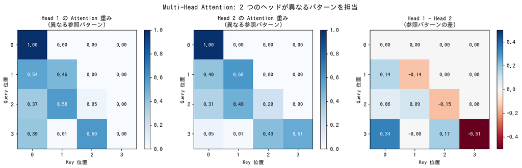

```python
# 2ヘッドのAttention重みを並べて比較
fig, axes = plt.subplots(1, 3, figsize=(14, 4))

for h in range(num_heads):
    w = all_weights[h]
    im = axes[h].imshow(w, cmap='Blues', aspect='equal', vmin=0, vmax=1)
    axes[h].set_title(f'Head {h+1} の Attention 重み\n（異なる参照パターン）', fontsize=11)
    axes[h].set_xlabel('Key 位置', fontsize=10)
    axes[h].set_ylabel('Query 位置', fontsize=10)
    axes[h].set_xticks(range(seq_len)); axes[h].set_yticks(range(seq_len))
    for i in range(seq_len):
        for j in range(seq_len):
            val = w[i,j]
            axes[h].text(j, i, f'{val:.2f}', ha='center', va='center',
                         fontsize=10, color='white' if val > 0.5 else 'black')
    plt.colorbar(im, ax=axes[h])

# 3枚目: 差分（パターンの違い）
diff = all_weights[0] - all_weights[1]
im2 = axes[2].imshow(diff, cmap='RdBu', aspect='equal', vmin=-0.5, vmax=0.5)
axes[2].set_title('Head 1 − Head 2\n（参照パターンの差）', fontsize=11)
axes[2].set_xlabel('Key 位置', fontsize=10)
axes[2].set_ylabel('Query 位置', fontsize=10)
axes[2].set_xticks(range(seq_len)); axes[2].set_yticks(range(seq_len))
for i in range(seq_len):
    for j in range(seq_len):
        axes[2].text(j, i, f'{diff[i,j]:.2f}', ha='center', va='center',
                     fontsize=10, color='white' if abs(diff[i,j]) > 0.3 else 'black')
plt.colorbar(im2, ax=axes[2])

plt.suptitle('Multi-Head Attention: 2 つのヘッドが異なるパターンを担当', fontsize=13, y=1.02)
plt.tight_layout()
plt.savefig('docs/nb02_multihead.png', dpi=120, bbox_inches='tight')
plt.show()
```

## まとめ：Attention の計算フロー

```
X (4, 4)
 │
 ├──@W_Q──→ Q (4,4) ─┐
 ├──@W_K──→ K (4,4) ─┼─→ Q@K^T/√d_k → softmax+mask → weights (4,4) ─→ @V → head_out (4,4)
 └──@W_V──→ V (4,4) ─┘
       ↑ これを num_heads 回繰り返す
 Concat → (4, d_model) → @W_O → MHA出力 (4, 4)
```

| 操作 | 入力 shape | 出力 shape | 意味 |
| --- | --- | --- | --- |
| `X @ W_Q` | `(4,4)×(4,4)` | `(4,4)` | Q の生成 |
| `Q @ K.T` | `(4,4)×(4,4)` | `(4,4)` | 全ペアのスコア |
| `/ √d_k` | `(4,4)` | `(4,4)` | 正規化 |
| `softmax` | `(4,4)` | `(4,4)` | 確率化 |
| `weights @ V` | `(4,4)×(4,4)` | `(4,4)` | 重み付き和 |
| Concat+`@W_O` | `(4,4)` | `(4,4)` | Multi-Head の統合 |

→ **次: `03_transformer_block.ipynb`** では MHA に LayerNorm と FFN を加えて完全なブロックを作ります。